# IODS course project

Juuso Hämäläinen

# Introduction to Open Data Science - Course Project

## Where did you find out about this course?

I heard about this course through email notification about it, sent by out faculty’s teaching assistant at the University of Eastern Finland.

## What are you expecting to learn during the course?

I am looking forward to learn more about R-programming and get more hands-on experience with statistical methods in data science.

## How am I feeling right now?

It is kinda busy with all the fuzz going on, but I am really looking forward to this course and to see what it has to offer.

## Here is the GitHub link

https://github.com/Juusoha/IODS-project

# Chapter 2 - Data Wrangling and Analysis

*This week went mostly working with R, as I suppose was the case for many others too. Week included also some learning exercises on DataCamp (with the R-exercises) and other studying (related to this and other cources). Lots of new interesting things to learn!*

## Overview of the data

Lets begin our journey to Data Analysis with R.

For the starters we need to set up some things and get the data to be analyze in this little project.

In this first section we import some useful libraries for data analyzing, load a data file, and take a deeper look into it.

```r
date()
```

```
## [1] "Thu Nov 05 23:44:54 2020"
```

```r
# Import libraries.
library(ggplot2)
library(GGally)
library(dplyr)

# Load data.
learning14 <- read.table("http://s3.amazonaws.com/assets.datacamp.com/production/course_2218/datasets/learning2014.txt", sep = ",", header = TRUE)

# Structure of data.
str(learning14)
```

```
## 'data.frame':    166 obs. of  7 variables:
##  $ gender  : chr  "F" "M" "F" "M" ...
##  $ age     : int  53 55 49 53 49 38 50 37 37 42 ...
##  $ attitude: num  3.7 3.1 2.5 3.5 3.7 3.8 3.5 2.9 3.8 2.1 ...
##  $ deep    : num  3.58 2.92 3.5 3.5 3.67 ...
##  $ stra    : num  3.38 2.75 3.62 3.12 3.62 ...
##  $ surf    : num  2.58 3.17 2.25 2.25 2.83 ...
##  $ points  : int  25 12 24 10 22 21 21 31 24 26 ...
```

```r
# Dimensions of the data.
dim(learning14)
```

```
## [1] 166   7
```

Data contains information about students who participated in the course on 2014. Variables present attributes and are based on questionnaires, while the observations present the answers given by participants. Original questionnaires were done using [Likert scale](https://en.wikipedia.org/wiki/Likert_scale).

Data is separated into following segments:

- Age (age)
- Gender (gender)
- Attitude scores (attitude)
- Exam points (points)
- Deep Learning related scores (deep)
- Strategic Learning related scores (stra)
- Surface-level Learning related scores (surf)

### About dimensions

- Data has 166 observations (rows) and 7 different variables (columns).

### About the structure of the data

- Datatypes: numeric, integer, character
- The data consist mostly of numeric data except ((age, points), int) (gender, chr)

## Graphical presentation of the data

Next we visualize the data in order to get a better idea how the data behaves.

Coloring of the data is meant to visualize the gender-distribution among the variables (*blue* being males and *red* females).

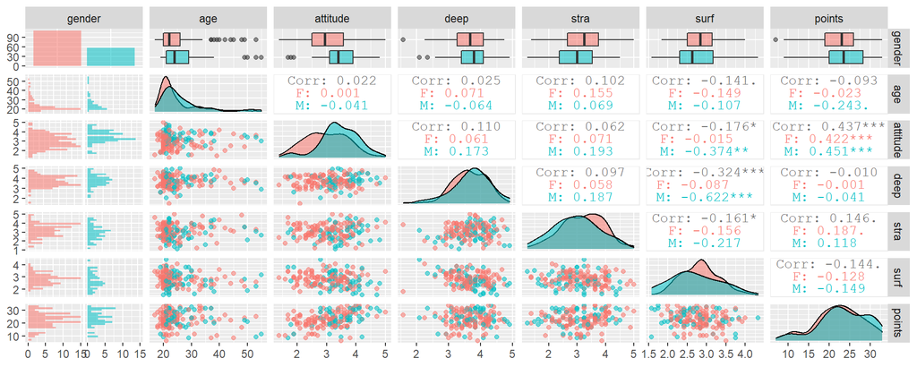

```r
# Plot the data.
image <- ggpairs(learning14, mapping = aes(col = gender, alpha = 0.3), lower = list(combo = wrap("facethist", bins = 20)))

# Show data.
image
```

From the image we can better see summaries of variables and thus analyze the data.

From the data presented we can directly see some interesting statistics about the students who participated in the course:

- Most participant were females
- The age distribution is quite similar for both genders (most of participants being relatively “young”) and males participants being overall a bit older than female participants.
- Males attitude towards statistics was bit higher than females
- Distribution of points seems to be quite similar for both genders
- Both genders were almost equally certain about questionnaires that fall in to the deep learning-category
  - Deep learning-category represents questionnaires about how thorough person is during learning process and how much they reflect what they learn to what they already know
- Females felt somewhat more certain about questionnaires that fall in to the strategic learning-category
  - Strategic learning-category represents questionnaires about organizing studying and how effective learner the person is
- Females were quite neutral on the questionnaires on surface learning-category
  - Surface learning-category represents questionnaires which are more about attitudes towards learning and how interested person is in general about trying to learn more than what is required

## Regression Model

Next we create a basic linear regression model which goal is to estimate the relationships between points and the following explanatory variables:

- Attitude
- strategic learning
- Surface learning

Explanatory variables were chosen highly based on the correlations presented and explained earlier on the graphical overview of the data.

The structure of the linear model is in form equation: $y = \alpha+\beta x + \epsilon$ and it is corresponding to the following formula, which we use to fit out model with given parameters in the next code section.

```r
# Create linear model.
lin_model <- lm(points ~ attitude + stra + surf, data = learning14)

# Summary of our linear model.
summary(lin_model)
```

```
##
## Call:
## lm(formula = points ~ attitude + stra + surf, data = learning14)
##
## Residuals:
##      Min       1Q   Median       3Q      Max
## -17.1550  -3.4346   0.5156   3.6401  10.8952
##
## Coefficients:
##             Estimate Std. Error t value Pr(>|t|)
## (Intercept)  11.0171     3.6837   2.991  0.00322 **
## attitude      3.3952     0.5741   5.913 1.93e-08 ***
## stra          0.8531     0.5416   1.575  0.11716
## surf         -0.5861     0.8014  -0.731  0.46563
## ---
## Signif. codes:  0 '***' 0.001 '**' 0.01 '*' 0.05 '.' 0.1 ' ' 1
##
## Residual standard error: 5.296 on 162 degrees of freedom
## Multiple R-squared:  0.2074, Adjusted R-squared:  0.1927
## F-statistic: 14.13 on 3 and 162 DF,  p-value: 3.156e-08
```

Output from the fitted model:

- Call: The formula for the model that is being fit
- Residuals: Estimates of experimental error, which are obtained by subtracting the observed responses from the predicted responses (vertical distance between a datapoint and the regression line, positive if above the line and negative if below)
- Coefficients: Estimates of the parameters of the model
  - Estimate to *Intercept* is the estimate of alpha-parameter and the estimate for *attitude, stra and surf* are the beta-parameters. Here we have estimated the effect of these parameters to points (points corresponds to y in the original equation for the linear model)
- Std. Error: Standard errors of alpha- and beta-values
- T and P value: Corresponding to statistical test (T-test and P-test) of the null-hypothesis, that the actual value of the beta-parameter would be zero
  - If the P-value is high, it is likely that the beta-parameter and the y-value does not have a statistical significant relationship. If the case would be so, the parameter is not likely to be the best parameter candidate for the linear model and changing it / dropping it off should be considered

An other thing we are interested in the summary of our fitted model, is the Multiple R-squared. The Multiple R-squared is coefficient of multiple determination for multiple regression. It is used for measuring how well the model fitted the data. The higher the value of Multiple R-Squared is, the better the model fit the data.

- As we can see, out model did not get really high value, but it does not necessarily mean that our model is not good
  - Studies that try to explain human-behavior have generally R-Squared values, which are less than 50%
- If the explanatory variables have statistical significance, we can still draw important conclusions from our model

## Residual vs Fitted values, Normal QQ-plot and Residuals vs Leverage

Next we are going to produce diagnostic plots of Residual vs Fitted values, Normal QQ-plot and Residuals vs Leverage.

R offers really simple and easy way to produce diagnostic plots using plot()-function. In plot()-function we can use the argument *which* to choose the plots we want to produce.

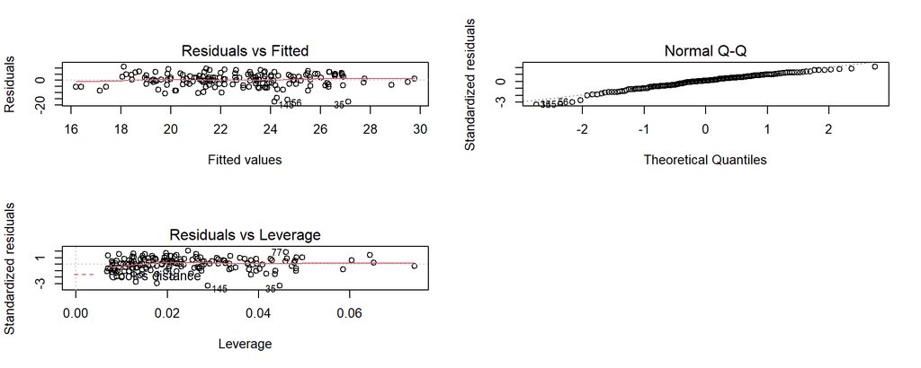

```r
# Draw diagnostic plots using the plot() function. Choose the plots 1, 2 and 5,
# corresponding to Residual vs Fitted values, Normal QQ-plot and Residuals vs Leverage.

# Draw all plots to same image.
par(mfrow = c(2,2))

# Plot the data and show it.
plot(lin_model, which = c(1,2,5))
```

Now we can draw assumptions from our model and validate it based on the diagnostic plots.

Analyzing residuals of the model can be used to check validity and model assumptions.

Here the assumptions are: * Errors are normally distributed * Errors are not correlated * Errors have constant variance * Size of the given error is not dependent on the explanatory variables

QQ-plot of the residuals is used to measure the normality assumption. * Assumption that the errors of the model are normally distributed * The better the points fit the line, the more reasonable the model is * If a lot of deviance occurs the normality assumption is questionable

Based on Residuals vs Fitted, we can see, that: * The residuals are spread around the zero-line, which indicates that the assumption that the relationship is linear, is reasonable * The residuals for a horizontal band around the zero line, indicating that errors have constant variance * The random pattern of residuals is quite uniform, suggesting that there is no ( or at least not many) outliers

Based on the Normal QQ-plot we can see that: * The residuals fit nicely to the line, indicating that the models normality assumption is reasonable

Based on the Residuals vs Leverage we can see that: * We can see that the line fits pretty well to the residuals, indicating that there are not outliers, which would cause fitting problems for the model

(more chapters to be added similarly as we proceed with the course!)